# Extração de séries do Google Trends

Caio Gonçalves

26-maio-2023

# Sobre Google Trends

O [Google Trends](https://trends.google.com.br/home) disponibiliza séries temporais que rastreiam o histórico de consulta de palavras em diversos países desde janeiro de 2004. Em alguns casos, as pesquisas podem ser específicas para estados ou províncias e em diferentes frequências temporais. No entanto, vale destacar que o Google Trends não fornece o volume exato das pesquisas realizadas. A medida utilizada é normalizada em uma escala de 0 a 100, em que o valor máximo (100) indica o ponto mais alto da consulta para o período de tempo selecionado pelo usuário.

O procedimento mencionado é necessário pois os dados do Google Trends representam amostras de buscas realizadas pelos usuários. Ademais, há algumas informações relevantes que devem ser destacadas a respeito desses dados:

1. os dados disponibilizados pelo aplicativo correspondem apenas aos termos mais populares, portanto, as palavras pesquisadas por um pequeno número de pessoas são excluídas.
2. para evitar a superestimação dos termos pesquisados, consultas repetidas realizadas por um mesmo usuário em um curto período de tempo são desconsideradas.
3. os apóstrofos e outros caracteres especiais são eliminados a fim de aumentar a precisão das informações apresentadas na série temporal.

Essas e outras informações estão presentes na [documentação do Google Trends](https://support.google.com/trends?sjid=14820757223693259603-SA#topic=6248052) e no [curso](https://newsinitiative.withgoogle.com/resources/lessons/google-trends-see-whats-trending-across-google-search-google-news-and-youtube/) preparado por eles.

Os dados do Google Trends são organizados em categorias por meio de um sistema de classificação baseado em linguagem natural. Essas categorias podem incluir temas como saúde, emprego, esportes, viagens, entre outros.

Os dados podem ser usados em diversas aplicações e em distintas áreas como mostrado por [Jun, S., Yoo, H. S. and Choi, S. (2017)](http://doi.org/10.1016/j.techfore.2017.11.009). Um estudo usando séries do Google Trends relacionadas a busca de empregos pode ser visualizado em [Gonçalves (2023, Cap. 8](https://ence.ibge.gov.br/images/Teses/Tese_CaioGoncalves.pdf)

# Extração de séries

Ao acessar a ferramenta do [Google Trends](https://trends.google.com.br/home) é possível pesquisar por um termo, por exemplo, `Minas Gerais`. Uma série será produzida de acordo com os filtros presentes: recorte geográfico, frequência temporal, categoria e tipo de pesquisa.

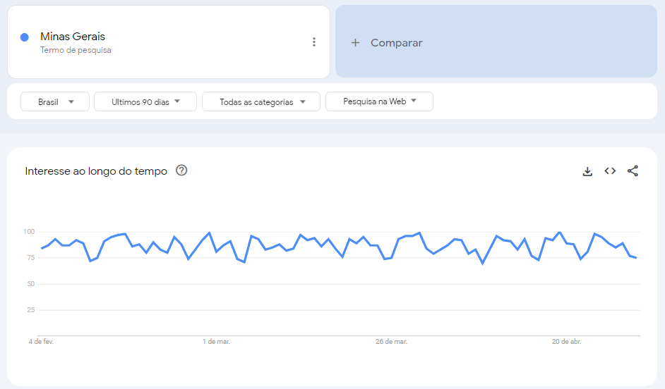

Além disso, o Google Trends oferece opções para compartilhamento e download dos dados em formato CSV, bem como a desagregação regional e a apresentação de assuntos e pesquisas relacionadas. Esses recursos, juntamente com outros detalhes relevantes, serão explorados a seguir, utilizando a linguagem de programação R e com o objetivo de extrair um número amplo de séries de forma automatizada.

Para realizar a extração, será utilizado o pacote [`gtrendsR`](https://cran.r-project.org/web/packages/gtrendsR/index.html) em que a principal função é a `gtrends`.

```r
if (!require("gtrendsR")){
  install.packages("gtrendsR")
  library(gtrendsR)
}
```

A documentação indica os argumentos da função e detalha suas funcionalidades, sendo necessário informar pelo menos uma palavra-chave (`keyword`) a ser buscada.

```r
?gtrends
```

```
## starting httpd help server ... done
```

Ao realizar uma pesquisa e inserir parâmetros, como `geo="BR"` para indicar a busca realizada no Brasil e `time="today 3-m"` para definir o período de tempo, o objeto `serie01` irá conter a série de interesse em `interest_over_time`.

```r
serie01 <- gtrends(keyword ="Minas Gerais",
                   geo = "BR",
                   time =  "today 3-m")
head(serie01$interest_over_time)
```

```
##         date hits      keyword geo      time gprop category
## 1 2023-02-22   80 Minas Gerais  BR today 3-m   web        0
## 2 2023-02-23   94 Minas Gerais  BR today 3-m   web        0
## 3 2023-02-24   87 Minas Gerais  BR today 3-m   web        0
## 4 2023-02-25   73 Minas Gerais  BR today 3-m   web        0
## 5 2023-02-26   84 Minas Gerais  BR today 3-m   web        0
## 6 2023-02-27   93 Minas Gerais  BR today 3-m   web        0
```

Também é possível realizar a busca com base em uma data específica, utilizando um intervalo definido no formato `AAAA-MM-DD AAAA-MM-DD` para obter informações diferentes das pré-definidas.

```r
serie02 <- gtrends(keyword ="currículo",
                   geo = "BR",
                   time =  "2012-01-01 2023-04-30")
head(serie02$interest_over_time)
```

```
##         date hits   keyword geo                  time gprop category
## 1 2012-01-01   22 currículo  BR 2012-01-01 2023-04-30   web        0
## 2 2012-02-01   23 currículo  BR 2012-01-01 2023-04-30   web        0
## 3 2012-03-01   24 currículo  BR 2012-01-01 2023-04-30   web        0
## 4 2012-04-01   21 currículo  BR 2012-01-01 2023-04-30   web        0
## 5 2012-05-01   23 currículo  BR 2012-01-01 2023-04-30   web        0
## 6 2012-06-01   21 currículo  BR 2012-01-01 2023-04-30   web        0
```

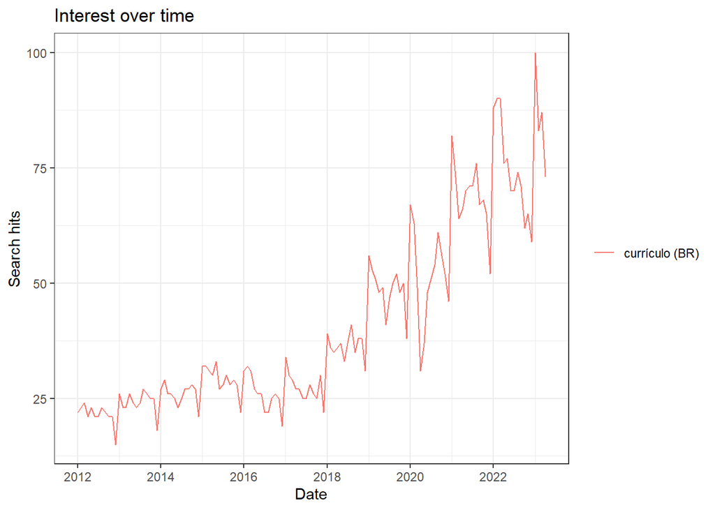

```r
# gráfico
plot(serie02)
```

Uma observação interessante é que a grafia das palavras, com ou sem acentuação, pode resultar em séries distintas. Veja, a seguir, o exemplo da palavra `currículo` sem acento.

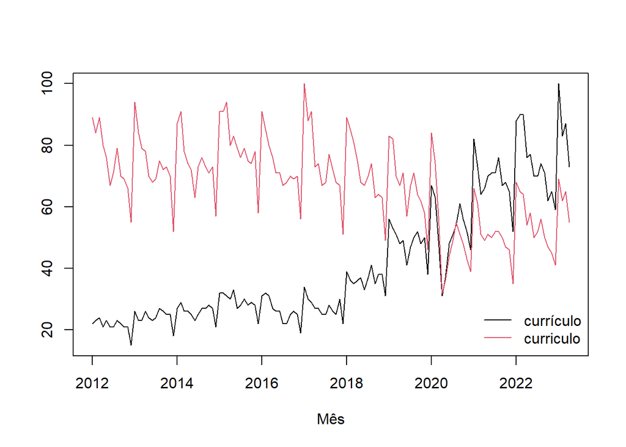

```r
serie03 <- gtrends(keyword ="curriculo",
                   geo = "BR",
                   time =  "2012-01-01 2023-04-30")
# gráfico
plot(ts.union(ts(serie02$interest_over_time$hits,start = c(2012,1), frequency = 12),
              ts(serie03$interest_over_time$hits,start = c(2012,1), frequency = 12)),
     plot.type = "single",col = c(1,2), ylab="", xlab="Mês")
legend("bottomright", legend = c("currículo","curriculo"),col = c(1,2), bty = 'n',lty = c(1,1))
```

## Aplicando filtro geográfico

Além disso, também é possível extrair séries temporais referentes às diferentes unidades da federação, por exemplo:

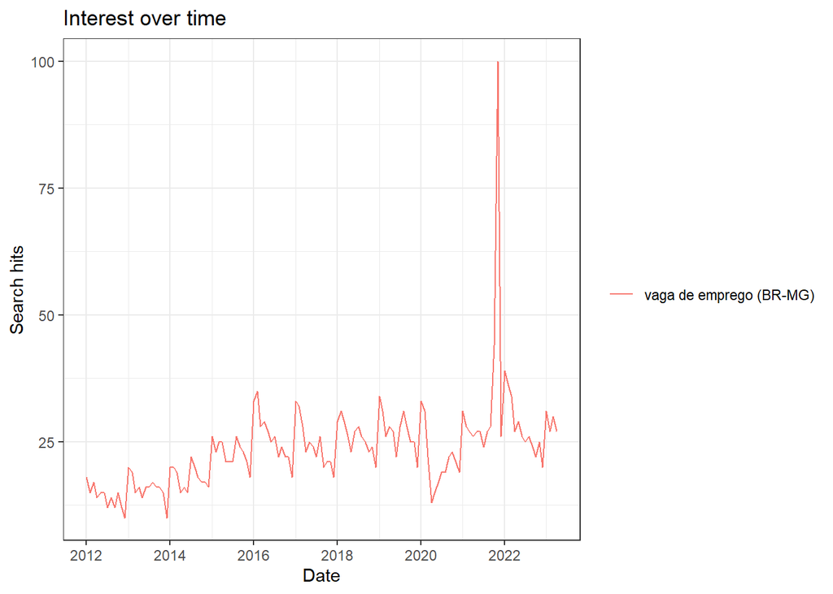

```r
serie04 <- gtrends(keyword ="vaga de emprego",
                   geo = "BR-MG",
                   time =  "2012-01-01 2023-04-30")
# gráfico
plot(serie04)
```

Uma palavra muito buscada em um período pode gerar um outlier, conforme exemplificado anteriormente. Portanto, é necessário realizar um tratamento dessas séries para fins estatísticos.

Também é possível extrair a mesma série para diferentes locais e realizar comparações entre eles. Nesse caso, o índice é construído com base nas buscas conjuntas em todos os locais. O valor 100 é atribuído ao ponto do tempo e ao local que apresenta o maior número de buscas.

```r
serie05 <- gtrends(keyword ="vaga de emprego",
                   geo = c("BR-MG","BR-SP"),
                   time =  "2012-01-01 2023-04-30")
head(serie05$interest_over_time)
```

```
##         date hits         keyword   geo                  time gprop category
## 1 2012-01-01   18 vaga de emprego BR-MG 2012-01-01 2023-04-30   web        0
## 2 2012-02-01   15 vaga de emprego BR-MG 2012-01-01 2023-04-30   web        0
## 3 2012-03-01   17 vaga de emprego BR-MG 2012-01-01 2023-04-30   web        0
## 4 2012-04-01   14 vaga de emprego BR-MG 2012-01-01 2023-04-30   web        0
## 5 2012-05-01   15 vaga de emprego BR-MG 2012-01-01 2023-04-30   web        0
## 6 2012-06-01   15 vaga de emprego BR-MG 2012-01-01 2023-04-30   web        0
```

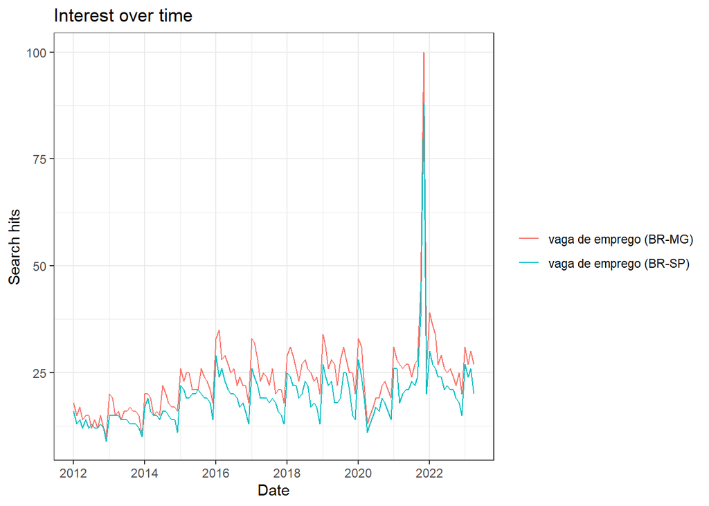

```r
# gráfico
plot(serie05)
```

Uma limitação é que as comparações são restritas a um máximo de cinco locais ou cinco palavras.

## Extraindo uma categoria

Os dados também são agrupados em categorias usando um mecanismo de classificação de linguagem natural, que inclui categorias como saúde, emprego, esportes, viagens, entre outras. A lista completa dessas categorias pode ser visualizada utilizando o pacote `gtrendsR`:

```r
data("categories")
View(categories)
```

Para realizar uma comparação, pode-se efetuar buscas com e sem a categoria `Jobs - 60` para a palavra-chave `vaga`, por exemplo:

```r
serie06a <- gtrends(keyword ="vaga",
                   geo = "BR-MG",
                   time =  "2012-01-01 2023-04-30",
                   category = 0)
serie06b <- gtrends(keyword ="vaga",
                   geo = "BR-MG",
                   time =  "2012-01-01 2023-04-30",
                   category = 60)
head(serie06a$interest_over_time)
```

```
##         date hits keyword   geo                  time gprop category
## 1 2012-01-01   41    vaga BR-MG 2012-01-01 2023-04-30   web        0
## 2 2012-02-01   41    vaga BR-MG 2012-01-01 2023-04-30   web        0
## 3 2012-03-01   42    vaga BR-MG 2012-01-01 2023-04-30   web        0
## 4 2012-04-01   36    vaga BR-MG 2012-01-01 2023-04-30   web        0
## 5 2012-05-01   36    vaga BR-MG 2012-01-01 2023-04-30   web        0
## 6 2012-06-01   30    vaga BR-MG 2012-01-01 2023-04-30   web        0
```

```r
head(serie06b$interest_over_time)
```

```
##         date hits keyword   geo                  time gprop category
## 1 2012-01-01   39    vaga BR-MG 2012-01-01 2023-04-30   web       60
## 2 2012-02-01   36    vaga BR-MG 2012-01-01 2023-04-30   web       60
## 3 2012-03-01   38    vaga BR-MG 2012-01-01 2023-04-30   web       60
## 4 2012-04-01   36    vaga BR-MG 2012-01-01 2023-04-30   web       60
## 5 2012-05-01   30    vaga BR-MG 2012-01-01 2023-04-30   web       60
## 6 2012-06-01   32    vaga BR-MG 2012-01-01 2023-04-30   web       60
```

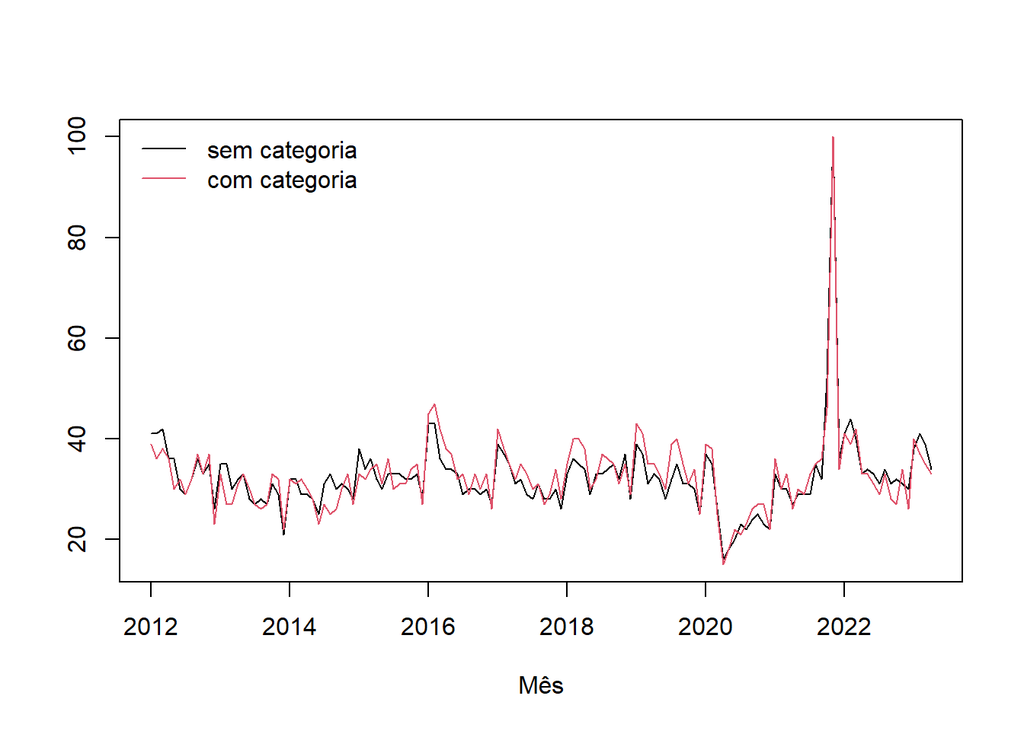

```r
# gráfico
plot(ts.union(ts(serie06a$interest_over_time$hits,start = c(2012,1), frequency = 12),
              ts(serie06b$interest_over_time$hits,start = c(2012,1), frequency = 12)),
     plot.type = "single",col = c(1,2), ylab="", xlab="Mês")
legend("topleft", legend = c("sem categoria","com categoria"),col = c(1,2), bty = 'n',lty = c(1,1))
```

As próprias categorias também podem ser extraídas ao não incluir uma `keyword`:

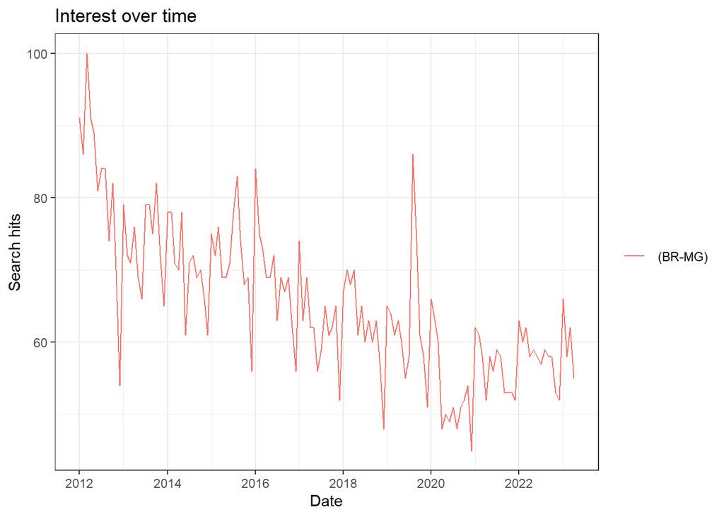

```r
serie07 <- gtrends(geo = "BR-MG",
                   time =  "2012-01-01 2023-04-30",
                   category = 60)
# gráfico
plot(serie07)
```

## Comparando séries

Assim como foi possível comparar diferentes localidades, também é possível comparar diferentes palavras-chave, com a limitação de até cinco palavras.

```r
serie08 <- gtrends(keyword =  c("currículo","curriculo","vaga de emprego","vaga","sine"),
                   geo = "BR-MG",
                   time =  "2012-01-01 2023-04-30",
                   category = 60)
head(serie08$interest_over_time)
```

```
##         date hits   keyword   geo                  time gprop category
## 1 2012-01-01   14 currículo BR-MG 2012-01-01 2023-04-30   web       60
## 2 2012-02-01   13 currículo BR-MG 2012-01-01 2023-04-30   web       60
## 3 2012-03-01   11 currículo BR-MG 2012-01-01 2023-04-30   web       60
## 4 2012-04-01   12 currículo BR-MG 2012-01-01 2023-04-30   web       60
## 5 2012-05-01   15 currículo BR-MG 2012-01-01 2023-04-30   web       60
## 6 2012-06-01    9 currículo BR-MG 2012-01-01 2023-04-30   web       60
```

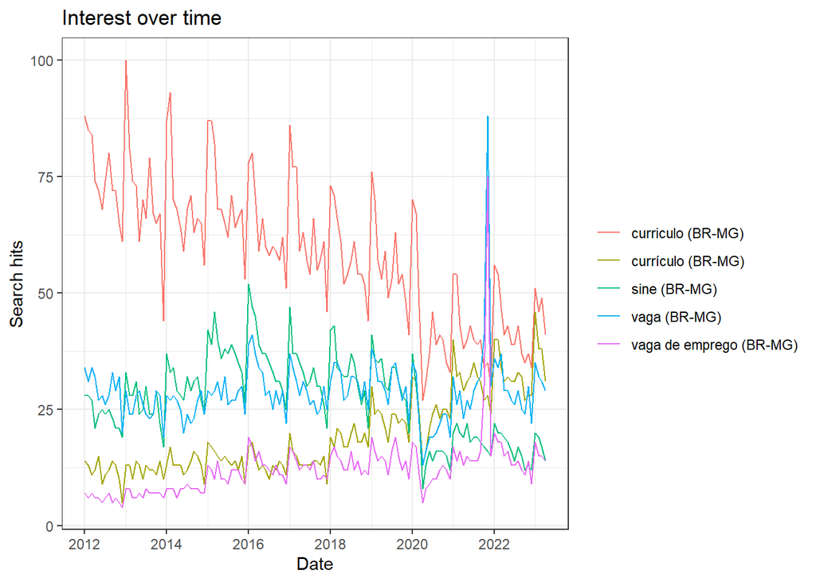

```r
# gráfico
plot(serie08)
```

## Extraindo palavras relacionadas

Explorando uma outra funcionalidade, a cada extração é possível obter uma lista de 50 palavras relacionadas.

```r
serie09 <- gtrends(keyword =  c("currículo"),
                   geo = "BR-MG",
                   time =  "2012-01-01 2023-04-30",
                   category = 0)
serie09$related_queries$value
```

```
##  [1] "curriculo"
##  [2] "fazer currículo"
##  [3] "lattes currículo"
##  [4] "modelo currículo"
##  [5] "lattes"
##  [6] "enviar currículo"
##  [7] "modelo de currículo"
##  [8] "como fazer currículo"
##  [9] "objetivo currículo"
## [10] "objetivo"
## [11] "o que é currículo"
## [12] "currículo online"
## [13] "fazer um currículo"
## [14] "currículo pdf"
## [15] "curriculum"
```

[output cut: 35 more lines]

É possível enriquecer um conjunto inicial de palavras ao expandir o grupo com termos do mesmo contexto. No entanto, é crucial realizar uma avaliação cuidadosa de cada palavra adicionada para garantir sua relevância ao contexto em estudo, alinhada com o objetivo pretendido.

```r
palavras <- unique(c("currículo",serie09$related_queries$value)) #conjunto de palavras únicas
length(palavras)
```

```
## [1] 45
```

# Computação paralela

Todos os exemplos anteriores foram construídos por meio da extração de uma ou mais séries. No entanto, para obter um conjunto mais amplo de séries, existem várias abordagens possíveis como a família de funções Apply:

```r
start_time <- Sys.time()
data01 <- sapply(palavras[1:25], function(i) gtrends(keyword =  i,
                   geo = "BR-MG",
                   time =  "2012-01-01 2023-04-30",
                   category = 60,
                   onlyInterest = TRUE)$interest_over_time$hits)
end_time <- Sys.time()
end_time - start_time
```

```
## Time difference of 24.38817 secs
```

Outra alternativa é aproveitar a computação paralela ao considerar atividades independentes. O pacote parallel oferece essa funcionalidade. Para obter mais detalhes sobre pacotes de computação paralela no R, recomenda-se consultar este [link](https://cran.r-project.org/web/views/HighPerformanceComputing.html).

Um aspecto relevante é o número de núcleos disponíveis na CPU.

```r
if (!require("parallel")){
  install.packages("parallel")
  library(parallel)
}
numCores<-detectCores()
numCores
```

```
## [1] 8
```

A ideia principal é criar um conjunto de instâncias paralelas do R para execução simultânea. Para alcançar isso, é necessário criar essas instâncias usando a função `makeCluster` e inserir em cada uma delas as informações necessárias para realizar a tarefa usando a função `clusterEvalQ`:

```r
# criando cópias
cl<- makeCluster(numCores-1)

# salva objetos
save.image("partial.Rdata")

# envia dados para cada uma das cópias
clusterEvalQ(cl,{load("partial.Rdata")
  library(gtrendsR)
})
```

```
## [[1]]
## [1] "gtrendsR"  "stats"     "graphics"  "grDevices" "utils"     "datasets"
## [7] "methods"   "base"
##
## [[2]]
## [1] "gtrendsR"  "stats"     "graphics"  "grDevices" "utils"     "datasets"
## [7] "methods"   "base"
##
## [[3]]
## [1] "gtrendsR"  "stats"     "graphics"  "grDevices" "utils"     "datasets"
## [7] "methods"   "base"
##
## [[4]]
## [1] "gtrendsR"  "stats"     "graphics"  "grDevices" "utils"     "datasets"
## [7] "methods"   "base"
##
## [[5]]
## [1] "gtrendsR"  "stats"     "graphics"  "grDevices" "utils"     "datasets"
## [7] "methods"   "base"
##
## [[6]]
## [1] "gtrendsR"  "stats"     "graphics"  "grDevices" "utils"     "datasets"
## [7] "methods"   "base"
##
## [[7]]
## [1] "gtrendsR"  "stats"     "graphics"  "grDevices" "utils"     "datasets"
## [7] "methods"   "base"
```

Realizando a extração anterior novamente, porém utilizando computação paralela:

```r
start_time <- Sys.time()
data02 <- parSapply(cl,palavras[1:25], function(i) gtrends(keyword =  i,
                   geo = "BR-MG",
                   time =  "2012-01-01 2023-04-30",
                   category = 60,
                   onlyInterest = TRUE)$interest_over_time$hits)
end_time <- Sys.time()
end_time - start_time
```

```
## Time difference of 7.135392 secs
```

```r
# stop cluster
stopCluster(cl)
```

# Extras

## Construindo um *ranking* relativo

Uma abordagem viável para construir um *ranking* de palavras é normalizar cada série com uma palavra única e relevante para o contexto em estudo. Para isso, é necessário extrair as séries em pares e calcular uma medida sintética que será usada para o *ranking*.

É válido tentar identificar a palavra com maior número de buscas no período e, preferencialmente, utilizá-la como a palavra de referência. A ideia é que essa palavra apresente o ponto máximo em comparação com todas as séries. No caso em que isso não ocorra, o *ranking* pode ser considerado uma aproximação, destacando um grupo de palavras mais buscadas, sem necessariamente refletir uma ordenação precisa.

O Google Trends atribui o valor `<1` para buscas menores que 1, mas não nulas. Portanto, as séries são extraídas como tipo `character`. Foi decidido considerar o valor `0` nessas situações e utilizar a média dos valores das séries extraídas. Com base nesses procedimentos, é possível criar uma função:

```r
f.ranking <- function(palavra, palavra_rel, geo, time, category){
  # extrai o par de séries
  data = gtrends(keyword =  c(palavra,palavra_rel),
                   geo = geo,
                   time =  time,
                   category = category,
                   onlyInterest = TRUE)$interest_over_time$hits
  # seleciona a série apenas da palavra em estudo
  data = data[1:(length(data)/2)]
  # substitui na base os menores que 1 por zero
  data[data=="<1"]=0
  # transforma em numérico
  data = as.numeric(data)
  # computa uma médida síntese
  media = mean(data,na.rm=TRUE)
  return(media)
}
```

Cria-se novamente as cópias:

```r
# criando cópias
cl<- makeCluster(numCores-1)

# salva objetos
save.image("partial.Rdata")

# envia dados para cada uma das cópias
clusterEvalQ(cl,{load("partial.Rdata")
  library(gtrendsR)
})
```

```
## [[1]]
## [1] "gtrendsR"  "stats"     "graphics"  "grDevices" "utils"     "datasets"
## [7] "methods"   "base"
##
## [[2]]
## [1] "gtrendsR"  "stats"     "graphics"  "grDevices" "utils"     "datasets"
## [7] "methods"   "base"
##
## [[3]]
## [1] "gtrendsR"  "stats"     "graphics"  "grDevices" "utils"     "datasets"
## [7] "methods"   "base"
##
## [[4]]
## [1] "gtrendsR"  "stats"     "graphics"  "grDevices" "utils"     "datasets"
## [7] "methods"   "base"
##
## [[5]]
## [1] "gtrendsR"  "stats"     "graphics"  "grDevices" "utils"     "datasets"
## [7] "methods"   "base"
##
## [[6]]
## [1] "gtrendsR"  "stats"     "graphics"  "grDevices" "utils"     "datasets"
## [7] "methods"   "base"
##
## [[7]]
## [1] "gtrendsR"  "stats"     "graphics"  "grDevices" "utils"     "datasets"
## [7] "methods"   "base"
```

Agora, finalmente, calcula-se o *ranking*:

```r
ranking <- parSapply(cl,palavras, function(i) f.ranking(palavra = i,
                                                       palavra_rel = "curriculo",
                                                       geo = "BR-MG",
                                                       time = "2012-01-01 2023-04-30",
                                                       category = 60))
```

Organizando e vizualizando o *ranking*:

```r
# ordena
ranking <- data.frame(média = sort(ranking, decreasing = TRUE))
ranking
```

```
##                                                média
## curriculo                                58.83088235
## lattes                                   45.66911765
## currículo                                19.41911765
## curriculum                               16.27205882
## objetivo                                  5.90441176
## fazer curriculo                           4.09558824
## lattes currículo                          2.62500000
## fazer currículo                           2.42647059
## como fazer um curriculo                   1.94117647
## enviar currículo                          1.60294118
## modelo currículo                          1.54411765
## como fazer currículo                      1.45588235
## objetivo currículo                        1.37500000
## modelo de currículo                       1.25735294
## jovem aprendiz                            1.12500000
## curriculo simples                         1.11764706
## currículo online                          1.08088235
## fazer um currículo                        1.06617647
## currículo primeiro emprego                0.85294118
## como fazer um currículo                   0.83823529
## objetivo para currículo                   0.82352941
## currículo pronto                          0.80147059
## currículo pdf                             0.67647059
## criar curriculo                           0.66176471
## currículo vitae                           0.63235294
## o que colocar no currículo                0.51470588
## modelos de currículo                      0.51470588
## meu currículo                             0.44852941
## o que é currículo                         0.38970588
## fazer currículo online                    0.38970588
## currículo online grátis                   0.27205882
## fazer currículo online grátis             0.23529412
## fazer currículo pelo celular              0.21323529
## como fazer currículo pelo celular         0.21323529
## currículo referência de minas gerais      0.16911765
## objetivo para currículo primeiro emprego  0.15441176
## fazer currículo em pdf                    0.14705882
## bncc                                      0.14705882
## gerador de currículo                      0.14705882
## o que é um currículo                      0.13235294
## objetivo profissional para currículo      0.11764706
## o que colocar no objetivo do currículo    0.11029412
## currículo pronto word                     0.10294118
## como fazer currículo online               0.07352941
## criar currículo online                    0.06617647
```

Pode-se também gerar uma núvem de palavras:

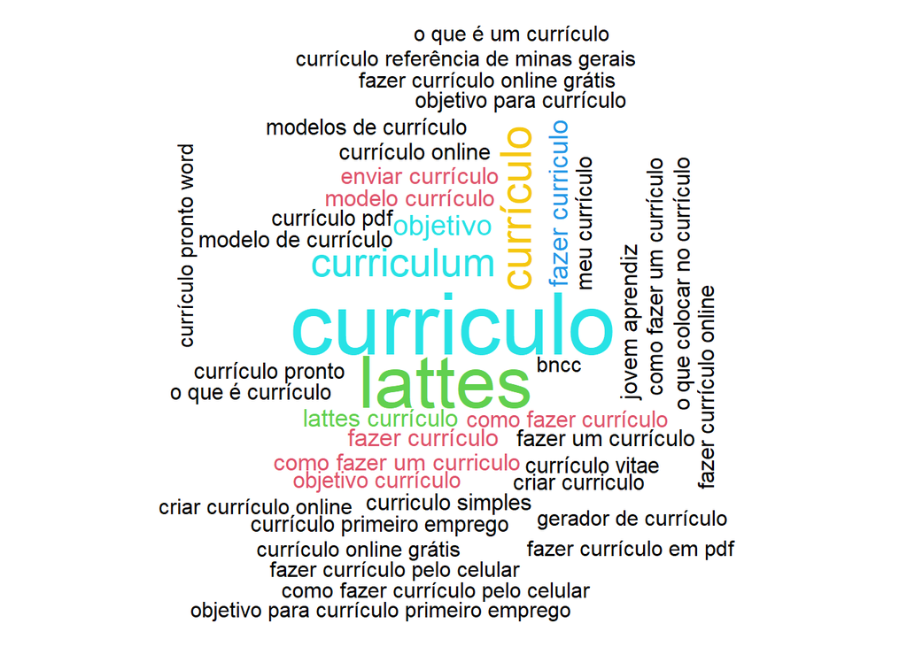

```r
if (!require("wordcloud")){
  install.packages("wordcloud")
  library(wordcloud)
}
set.seed(32)  #para reproduzir a mesma núvem

wordcloud(words = rownames(ranking),
          freq = ranking$média,
          scale = c(4, 1),  min.freq=0, max.words = 50,
          random.order = FALSE,
          color = 1:nrow(ranking))
```

# Referências

Fellows, I. (2018). wordcloud: Word Clouds. URL: [link](https://cran.r-project.org/web/packages/wordcloud/index.html)

Gonçalves, C. C. S. (2023) Produção de indicadores do mercado de trabalho com modelos de séries temporais de pesquisas repetidas Tese (Doutorado em População, Território e Estatísticas Públicas) – Escola Nacional de Ciências Estatística - Instituto Brasileiro de Geografia e Estatística, Rio de Janeiro. URL: [link](https://ence.ibge.gov.br/images/Teses/Tese_CaioGoncalves.pdf)

Google (2022) Google Trends lessons. URL: [link](https://newsinitiative.withgoogle.com/training/lessons?tool=Google%20Trends&image=trends)

Jun, S., Yoo, H. S. and Choi, S. (2017) Ten years of research change using Google Trends: From the perspective of big data utilizations and applications. Technological Forecasting and Social Change. URL:[link](http://doi.org/10.1016/j.techfore.2017.11.009)

Massicotte, P. (2021) gtrendsr: Perform and display Google Trends queries. URL: [link](https://cran.r-project.org/web/packages/gtrendsR/index.html)

R Core Team (2022) Package parallel. URL: [link](https://stat.ethz.ch/R-manual/R-devel/library/parallel/doc/parallel.pdf)

# Contribuições

Dúvidas, contribuições, comentários e sugestões podem ser direcionadas para o e-mail caio.goncalves@fjp.mg.gov.br ou diretamente no Github por meio do [link](https://github.com/FundacaoJoaoPinheiro/R/tree/main/Workshops/extracao_gtrends)

# Licença

[Extração de séries do Google Trends](https://rpubs.com/caiocgonc/googletrends) by [Caio Gonçalves](https://github.com/caiocgonc) is licensed under Attribution-ShareAlike 4.0 International

[figure not shown]

# Citação

Sugestão de citação: Gonçalves, C. Extração de séries do Google Trends. Belo Horizonte, Brasil: Rpubs, 2023. Disponível em https://rpubs.com/caiocgonc/googletrends.